# xgboost

[figure not shown]

Autores

Correo

Valentina Díaz Torres

Valentina.diaz@cunef.edu

Francisco del Val Yague

Francisco.delval@cunef.edu

Alejandro García Girón

A.garciagiron@cunef.edu

```
Index(['member_id', 'loan_amnt', 'funded_amnt', 'funded_amnt_inv', 'term',
       'int_rate', 'installment', 'emp_length', 'home_ownership', 'annual_inc',
       ...
       'hardship_payoff_balance_amount', 'hardship_last_payment_amount',
       'disbursement_method', 'debt_settlement_flag',
       'debt_settlement_flag_date', 'settlement_status', 'settlement_date',
       'settlement_amount', 'settlement_percentage', 'settlement_term'],
      dtype='object', length=134)
Las columna son iguales
Las columna son iguales
Las columna son iguales
Las columna son iguales
Las columna son iguales
Las columna son iguales
Las columna son iguales
term
pymnt_plan
initial_list_status
application_type
hardship_flag
disbursement_method
debt_settlement_flag
```

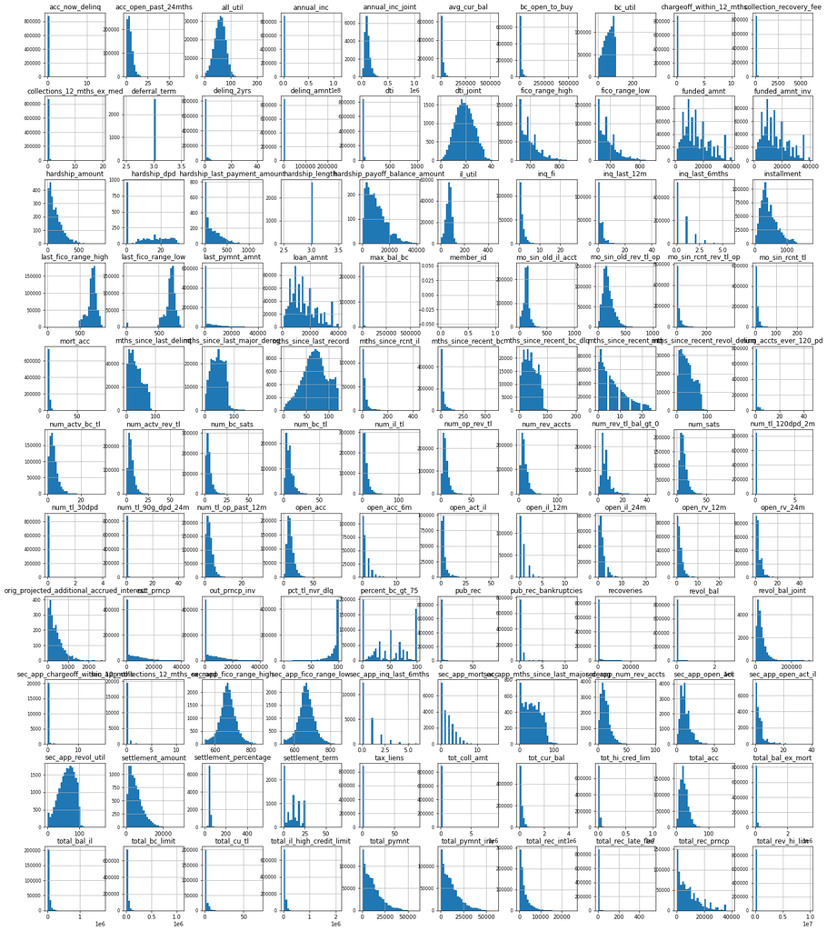

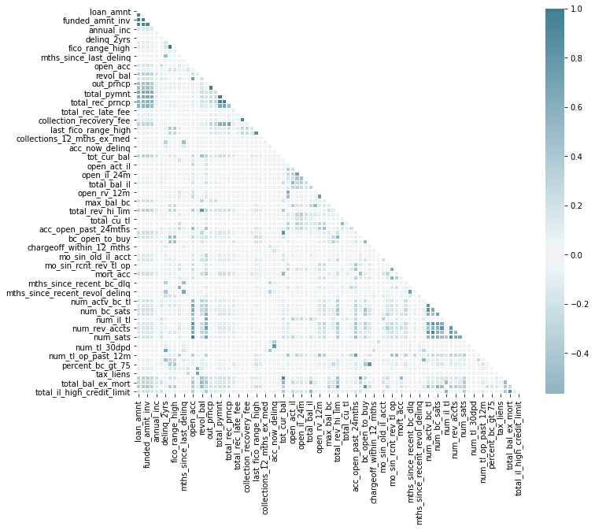

```python
import sys
sys.path.append("../00_eda_ingeniera_variables")
from eda_ingenieria_de_variable import *
```

## XGBOOST MODEL

**1. Definición**

XGBoost es una implementación de código abierto popular y eficiente del algoritmo de gradiente de árboles reforzados. Gradient boosting es un algoritmo de aprendizaje supervisado, que intenta predecir con precisión una variable objetivo combinando las estimaciones de un conjunto de modelos más simples y débiles.

**2. Librerias**

```python
# data frame
import pandas as pd
import numpy as np


!pip install xgboost pandas sklearn
import xgboost as xgb
import seaborn as sns
import matplotlib.pyplot as plt

# sklearn
from sklearn import metrics
from sklearn.model_selection import train_test_split
from sklearn.metrics import accuracy_score, confusion_matrix,roc_auc_score,roc_curve, plot_roc_curve,classification_report
from sklearn.metrics import plot_confusion_matrix
from sklearn.metrics import confusion_matrix
from sklearn.metrics import roc_auc_score
from sklearn.metrics import roc_curve

# guardar modelo
import pickle
```

**3. Training - Test**

```python
#Separamos la variable target del resto del dataset
X = data.drop(['loan_status_Paga'],axis=1)

#Analogamente que arriba pero esta vez obviamos el resto de la target
Y = data['loan_status_Paga']


 # 80% Train 20% Test
X_train, X_test, Y_train, Y_test = train_test_split(X, Y, test_size = 0.2)
```

**4. Modelo XGBOOST**

```python
data.info()
```

```
<class 'pandas.core.frame.DataFrame'>
Int64Index: 462191 entries, 0 to 462190
Data columns (total 57 columns):
 #   Column                          Non-Null Count   Dtype
---  ------                          --------------   -----
 0   annual_inc                      462191 non-null  float64
 1   dti                             462191 non-null  float64
 2   delinq_2yrs                     462191 non-null  int64
 3   fico_range_low                  462191 non-null  int64
 4   inq_last_6mths                  462191 non-null  int64
 5   mths_since_last_delinq          462191 non-null  float64
 6   mths_since_last_record          462191 non-null  float64
 7   pub_rec                         462191 non-null  int64
 8   revol_bal                       462191 non-null  int64
 9   collections_12_mths_ex_med      462191 non-null  int64
```

[output cut: 49 more lines]

```python
data['emp_length'] = data.emp_length.astype(float)
data['home_ownership'] = data.emp_length.astype(float)
```

```python
data.info()
```

```
<class 'pandas.core.frame.DataFrame'>
Int64Index: 462191 entries, 0 to 462190
Data columns (total 57 columns):
 #   Column                          Non-Null Count   Dtype
---  ------                          --------------   -----
 0   annual_inc                      462191 non-null  float64
 1   dti                             462191 non-null  float64
 2   delinq_2yrs                     462191 non-null  int64
 3   fico_range_low                  462191 non-null  int64
 4   inq_last_6mths                  462191 non-null  int64
 5   mths_since_last_delinq          462191 non-null  float64
 6   mths_since_last_record          462191 non-null  float64
 7   pub_rec                         462191 non-null  int64
 8   revol_bal                       462191 non-null  int64
 9   collections_12_mths_ex_med      462191 non-null  int64
```

[output cut: 49 more lines]

```python
%%time
estimator = xgb.XGBClassifier(n_estimators=1000)

estimator.fit(X_train, Y_train)
```

[output not shown]

```
XGBClassifier(base_score=0.5, booster='gbtree', colsample_bylevel=1,
              colsample_bynode=1, colsample_bytree=1, gamma=0, gpu_id=-1,
              importance_type='gain', interaction_constraints='',
              learning_rate=0.300000012, max_delta_step=0, max_depth=6,
              min_child_weight=1, missing=nan, monotone_constraints='()',
              n_estimators=1000, n_jobs=6, num_parallel_tree=1, random_state=0,
              reg_alpha=0, reg_lambda=1, scale_pos_weight=1, subsample=1,
              tree_method='exact', validate_parameters=1, verbosity=None)
```

```python
#hacemos la prediccion del modelo
pred = estimator.predict(X_test)
print(pred)
```

```
[1 1 1 ... 1 1 1]
```

```python
#evaluamos la precisión del mismo
accuracy_score(Y_test, pred)
```

```
0.7498674801761162
```

**4.Matrices de Confusión**

```python
confusion_matrix(Y_test, pred)
```

```
array([[ 5213, 18301],
       [ 4821, 64104]], dtype=int64)
```

**Matriz de Confusión**

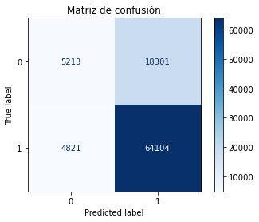

```python
disp = plot_confusion_matrix(estimator, X_test, Y_test,
                                 #display_labels= Y,
                                 cmap=plt.cm.Blues);
disp.ax_.set_title('Matriz de confusión');
```

**Matriz de Confusión normalizada**

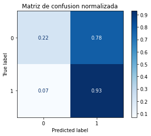

```python
disp = plot_confusion_matrix(estimator, X_test, Y_test,
                                 #display_labels= Y,
                                 cmap=plt.cm.Blues,
                                 normalize= 'true');
disp.ax_.set_title('Matriz de confusion normalizada');
```

A diferencia de la anterior que nos expresa el número por casos esta nos los devuelve en tanto por uno lo cual se presenta como más intuitivo

**Curva ROC**

Esta es una representación gráfica de la sensibilidad frente a la especificidad para un sistema clasificador binario según se varía el umbral de discriminación.

[figure not shown]

```python
logit_roc_auc = roc_auc_score(Y_test, estimator.predict(X_test))
fpr, tpr, thresholds = roc_curve(Y_test, estimator.predict_proba(X_test)[:,1])
plt.figure()
plt.plot(fpr, tpr, label='XGBoost (area = %0.2f)' % logit_roc_auc)
plt.plot([0, 1], [0, 1],'r--')
plt.xlim([0.0, 1.0])
plt.ylim([0.0, 1.05])
plt.xlabel('False Positive Rate')
plt.ylabel('True Positive Rate')
plt.title('Receiver operating characteristic')
plt.legend(loc="lower right")
plt.savefig('XGBoost')
plt.show()
```

**Estadísticos**

```python
print(classification_report(Y_test, pred))
```

```
              precision    recall  f1-score   support

           0       0.52      0.22      0.31     23514
           1       0.78      0.93      0.85     68925

    accuracy                           0.75     92439
   macro avg       0.65      0.58      0.58     92439
weighted avg       0.71      0.75      0.71     92439
```

**Guardado del Modelo**

```python
model = estimator
filename = 'XGB.sav'
pickle.dump(model, open(filename, 'wb'))
```